# Estadistica descriptiva y normalizacion de datos

# Introduccion

Ahora que ya sabemos como procesar y modificar nuestras tablas, es momento de aplicar todo lo aprendido a una de las bases del metodo cientifico: **el analisis estadistico**

Si bien hay muchas maneras de analizar datos y aun mas metodos para ello. A lo largo de este modulo vamos a aprender un flujo basico para determinar que tipo de analisis es el mas idoneo para cada tipo de datos.

```r
# Libraries

library(dplyr) # manipulacion de datos, funciones, modificar columans, filtrar, reordenar, calculos, etc
library(tidyr) # modificando las funciones de datos
library(readr) # leer y escribir csvs
library(udunits2) # conversion de unidades


# Data

Plantas <- read.csv("~/RStudio/CursoInnovak/Materiales/Tabla_plantas.csv")

Stream <- read.csv("~/Rstudio/CursoInnovak/Materiales/stream.csv")

Acidos <- read.csv("~/RStudio/CursoInnovak/Materiales/Acidos_ex.csv")

Fosf <- read.csv("~/RStudio/CursoInnovak/Materiales/phosphorus.csv")

Medidas_clase <- read.csv("~/RStudio/CursoInnovak/Materiales/Class-data.csv")
```

# Estadistica descriptiva

En la clase anterior ya vimos, los valores mas importantes dentro de la estadistica descriptiva. El objetivo de la estadística descriptiva es describir los datos observados de forma sintética y significativa para poder analizarlos mejor. La estadística descriptiva comprende tres categorías principales: Te describe los datos observados de manera simple pero no te dira cual es mejor que otro.

1. Distribución de frecuencias
   - Count: n(), n_distinct() en dplyr o count()
   - Range: min(), max(), quantile()
2. Medidas de tendencia central
   - Center: mean() *que es el promedio*, median() *que es la mediana se usa cuando hay una dispersion muy alta*
3. Medidas de variabilidad.
   - Spread que es dispersion: sd() *que es desviacion estandar si usamos media*, IQR() *que es el rango intercuartilico*, mad() *si cualculas mediana usar el mad y no la desviacion estandar*

```r
mad(Medidas_clase$Height.cm)
```

```
[1] 11.26776
```

# Ejercicio

Usando el data fame de plantas cada quien va a elegir una variable y comparar media, mediana, desviacion estandar y desviacion de la mediana

```r
mad(Plantas$root_tip_count, na.rm = TRUE)
```

```
[1] 109.7124
```

# Normalizacion de datos

La distribucion nomral de datos se caracteriza por gran cantidad de datos alredador de la media y pocos datos en las colas de forma *simetrica*.

Es decir si conocemos la media y la desviafcion estandar son conocidos la probabilidad de que cualqueir obsrvacion futura caiga dentro de un rango especifico ya es conocida.

Todos los anaisis parametricos tiene como primera suposicion que los datos que se van a usar en el analisis siguien una distribucion normal e ahi la importancia de normalizar los datos.

si bien existen tests para datos no parametricos estos son mas estrictos y no siempre van a arrojar diferencias a pesar de que si las hayan.

## Como saber si nuestros datos son normales?

```r
# Shapiro-wilk normality test
shapiro.test(Stream$Temp.degC)
```

```
    Shapiro-Wilk normality test

data:  Stream$Temp.degC
W = 0.97518, p-value = 0.0856
```

El test de shapiro es muy estricto por lo que datos que tengan un p-value cerca de 0.05 y un histograma y qqplot mas o menos lineal pueden ser considerados para estadisticas parametricas. Por ello cuando trabajamos con datos hay que empezar revisando el test shapiro y de ahi continuar el analisis para deterimar si el set de datos es normal.

## Ejercicio

En el data frame *plantas* cada quien elija una variale y determinen si siguien o no una distribucion normal. JUSTIFICAR

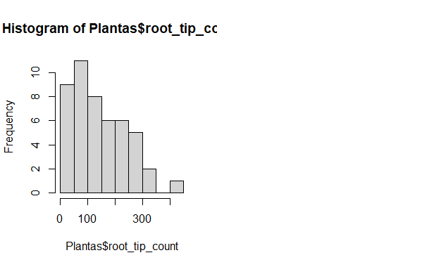

### Como checar normalidad en muchos datos

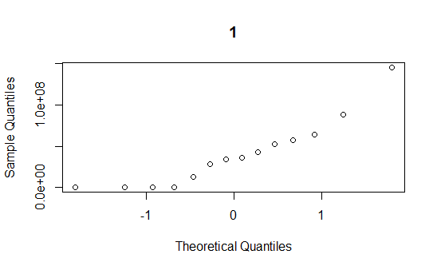

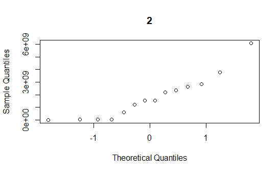

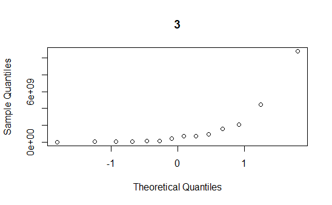

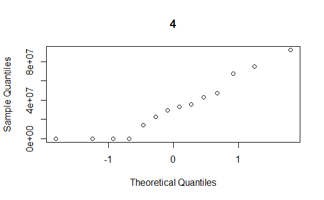

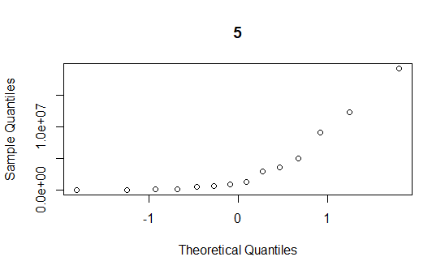

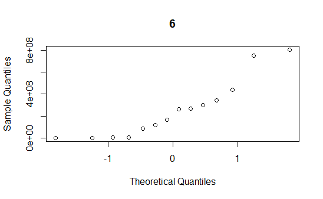

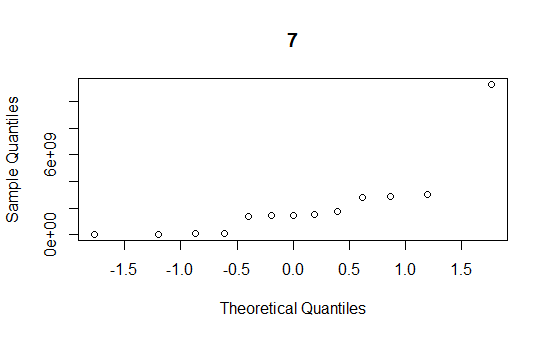

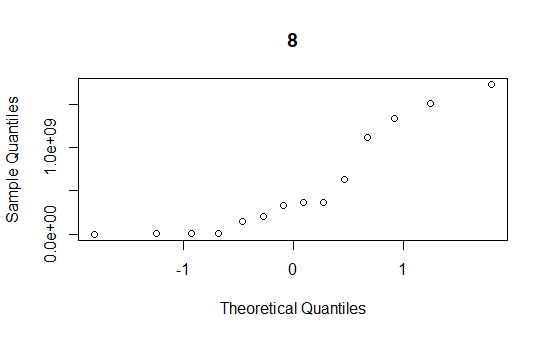

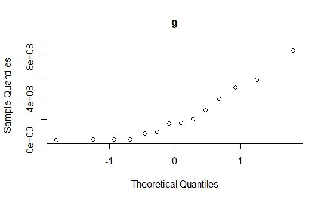

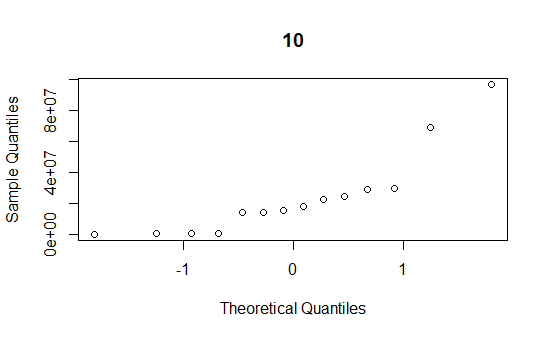

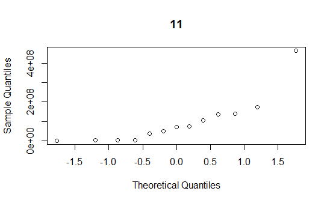

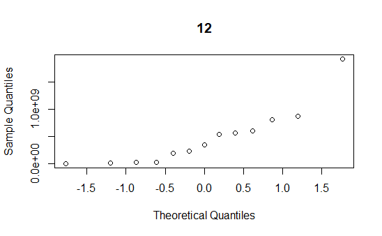

[3 more figures not shown]

### Ejercicio

Modifiquen el codigo anterior para checar normalidad en todas las variables del dataframe *plantas*

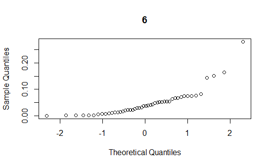

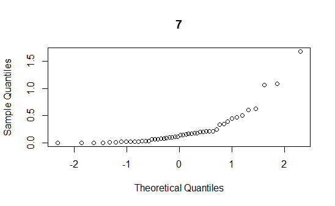

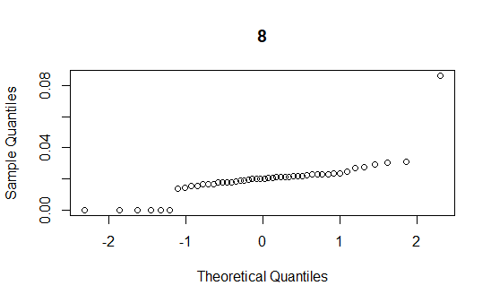

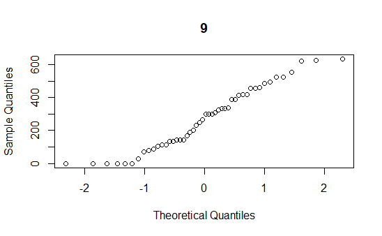

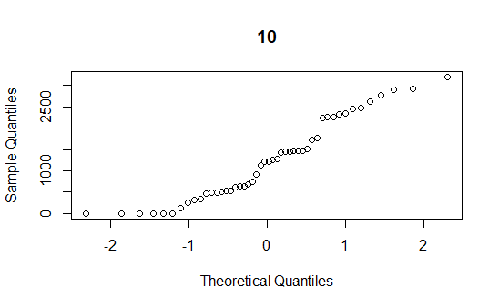

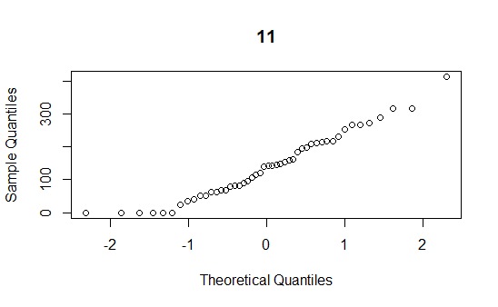

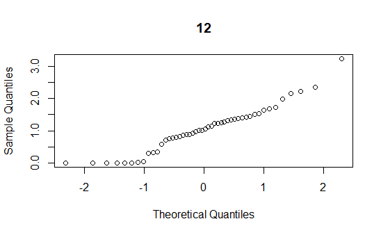

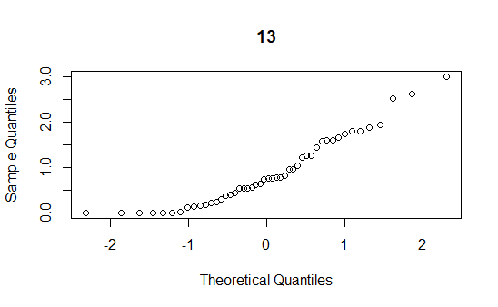

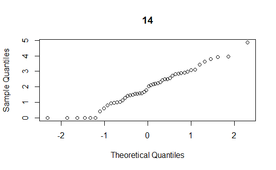

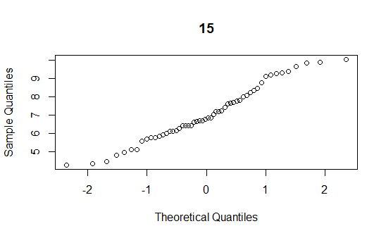

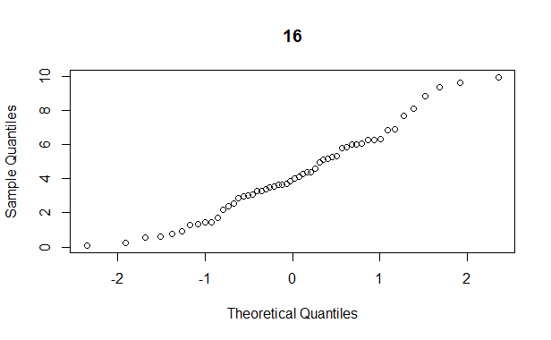

## Como transformar datos para que sean normales

La transformacion aplicada dependera del tipo de datos y el tipo de distribucion o sesgo que tenga:

- Sesgo a la izquierda = esta la colita a la izquierda
- Sesgo al a derecha = la colita esta a la derecha
- Sesgo uniforme = todo esta al mismo nivel
- Sesgo simetrical = como una montaña
- Sesgo bimodal = tienen dos picos es la mas dificil de modificar

Aunque existen ecuaciones mas complejas para sets de datos especificos, no es recomendable transformar los datos hasta que se vuelven numeros artificiales que representan verdaderas diferencias biologicas. Por ello si despues de dos metodos de transformacion son usados y los datos siguen sin ser normales lo mejor es usar un metodo no parametrico para analizarlos.

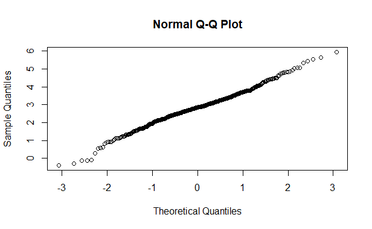

```r
qqnorm(log(Fosf$TDP))
```

### Ejercicio final

De las variables que concluimos no eran normales en el dataframe *platas* elegir el mejor metodo de transformacion para normalizarlos y asi poder analizarlos. Y enseñar shapiro, histograma, qqplot antes y despues de normalizar.

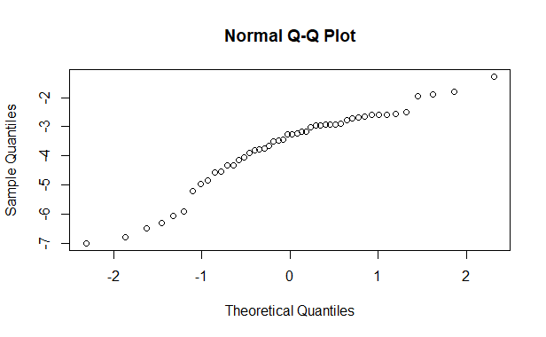